# Análise Folha de Pagamento Prefeitura Porto Alegre - RS

José Mateus e Gabriel Nachtigal

02 de junho de 2019

## Análise e Coleta de dados

### Introdução

Essa análise busca demonstrar de forma ampla e direta os conceitos de Data Mining, também conhecido como Mineração de Dados, e suas possíveis aplicações em nosso dia a dia. Análise a seguir utiliza algumas técnicas e algoritmos especificos na *Linguagem R* que normalamente são utilizados por **Cientistas de Dados** para analisar e chegar a uma conclusão a partir dos dados coletados.

Escolhemos uma base de dados pública da Prefeitura de Porto Alegre - RS, referente a folha de remuneração dos servidores do estado. A extração dos dados foi realizada pelo portal de transparência da prefeitura. link: http://portaltransparencia.procempa.com.br/portalTransparencia/fpRemuneracaoPesquisa.do?viaMenu=true

## Coleta de Dados

### Script em R

Bibliotecas utilizadas para desenvolver o código em Linguagem R:

```r
library(tidyverse)
library(data.table)
library(genderBR)
```

- **tidyverse** - Pacote que contempla uma serie de outros pacores, voltado para análise e manipulação de dados;
- **data.table** - Pacote utilizado para trabalhar data tables de forma mais rápida e dinâmica;
- **genderBR** - Pacote para prever e relatar o gênero de nomes brasileiros usando os dados do Censo do Instituto Brasileiro de Geografia e Estatística.

### Lendo os dados

```r
#coletando dados
dados_salarios_poa <- data.frame() #Criando data frame
nome_arquivo <- list.files('arquivos/') #Listando todos os arquivos do diretorio
lista_arquivos <- NULL #Lista auxiliar

for (i in 1:length(nome_arquivo)) { #Lendo arquivos e armazenando em uma lista
  lista_arquivos[[i]] <- read.csv2(file = paste0('arquivos/', nome_arquivo[i]),
                                   sep = ';',
                                   stringsAsFactors = FALSE)
  cat(nome_arquivo[i],'\n')
}

for (i in 1:length(lista_arquivos)) { #Unificando todos arquivos em um dataframe
  dados_salarios_poa <- rbind(dados_salarios_poa, lista_arquivos[[i]])
}
```

No data frame gerado, chegou a hora de tratar os dados para facilitar a análise. Uma das principais dificuldades na hora de analisar os dados, é trabalhar com caracteres especiais e variaveis com letras maiúsculas e minusculas. Para isso geramos uma serie de funções para validar e limpar os dados,

Removendo caracteres especiais:

```r
remove_acento <- function(str,pattern="all") { #Function para limpar os caracteres especiais
  if(!is.character(str))
    str <- as.character(str)

  pattern <- unique(pattern)

  if(any(pattern=="Ç"))
    pattern[pattern=="Ç"] <- "ç"

  symbols <- c(
    acute = "áéíóúÁÉÍÓÚýÝ",
    grave = "àèìòùÀÈÌÒÙ",
    circunflex = "âêîôûÂÊÎÔÛ",
    tilde = "ãõÃÕñÑ",
    umlaut = "äëïöüÄËÏÖÜÿ",
    cedil = "çÇ"
  )

  nudeSymbols <- c(
    acute = "aeiouAEIOUyY",
    grave = "aeiouAEIOU",
    circunflex = "aeiouAEIOU",
    tilde = "aoAOnN",
    umlaut = "aeiouAEIOUy",
    cedil = "cC"
  )

  accentTypes <- c("´","`","^","~","¨","ç")

  if(any(c("all","al","a","todos","t","to","tod","todo")%in%pattern))
    return(chartr(paste(symbols, collapse=""), paste(nudeSymbols, collapse=""), str))

  for(i in which(accentTypes%in%pattern))
    str <- chartr(symbols[i],nudeSymbols[i], str)

  return(str)
}
```

Ajustando os nomes para um padrão em letras minúsculas e sem espaço:

```r
ajustar_nomes <- function(x){ #Function para ajustar o nome das variaeis
  x%>%
    stringr::str_trim() %>%
    stringr::str_to_lower() %>%
    remove_acento() %>%
    stringr::str_replace_all("[/' '.()]", "_") %>%
    stringr::str_replace_all("_+", "_") %>%
    stringr::str_replace("_$", "") %>%
    stringr::str_replace_all("\\.", "_")
}
```

### Tratando os dados

```r
#tratnado os dados
nomes_colunas <- ajustar_nomes(colnames(dados_salarios_poa)) #Formatando o nome das colunas
names(dados_salarios_poa) <- nomes_colunas #Adicionando ao data frame os nomes já formatados

dados_salarios_poa <- dados_salarios_poa %>% #Limpando e formatando os dados númericos.
  filter(
    remuneracao_apos_deducoes_obrigatorias > 0.00 #Filtrando servidores com remuneração > 0
  ) %>%
  mutate(
    competencia                            = paste0(substr(competencia, 4, 7), '-', substr(competencia, 1, 2)),
    remuneracao_basica_bruta               = formata_string_para_double(remuneracao_basica_bruta),
    gratificacao_natalina                  = formata_string_para_double(gratificacao_natalina),
    ferias                                 = formata_string_para_double(ferias),
    outras_remuneracoes_eventuais          = formata_string_para_double(outras_remuneracoes_eventuais),
    abate_teto                             = formata_string_para_double(abate_teto),
    imposto_de_renda_retido_na_fonte       = formata_string_para_double(imposto_de_renda_retido_na_fonte),
    previdencia_oficial                    = formata_string_para_double(previdencia_oficial),
    remuneracao_apos_deducoes_obrigatorias = formata_string_para_double(remuneracao_apos_deducoes_obrigatorias),
    demais_deducoes                        = formata_string_para_double(demais_deducoes),
    diarias                                = formata_string_para_double(diarias),
    demais_verbas_indenizatorias           = formata_string_para_double(demais_verbas_indenizatorias),
    grupo_salario                          = case_when(between(remuneracao_apos_deducoes_obrigatorias, 0, 1000) ~ 'R$ 0 - R$ 1.000',
                                                       between(remuneracao_apos_deducoes_obrigatorias, 1001, 3000) ~ 'R$ 1.001 - R$ 3.000',
                                                       between(remuneracao_apos_deducoes_obrigatorias, 3001, 6000) ~ 'R$ 3.001 - R$ 6.000',
                                                       between(remuneracao_apos_deducoes_obrigatorias, 6001, 9000) ~ 'R$ 6.001 - R$ 9.000',
                                                       between(remuneracao_apos_deducoes_obrigatorias, 9001, 12000) ~ 'R$ 9.001 - R$ 12.000',
                                                       between(remuneracao_apos_deducoes_obrigatorias, 12001, 15000) ~ 'R$ 12.001 - R$ 15.000',
                                                       TRUE ~ '> R$ 15.000'),
    genero                                 = get_gender(nome) #Utilizando o pacote genderBR para predizer o gênero a partir do nome do servidore
  )
```

### Separando e selecionando dados para análise

Com a base de servidores alimentada com todas as variáveis necessárias para cluesterizar o público. É executado um bloco de código que aplica todos os agrupamentos e cálculos para retorna somente o público desejado.

```r
database_salarios <- dados_salarios_poa %>%
  group_by(
    competencia,
    genero,
    orgao,
    orgao_de_exercicio,
    tipo_de_folha,
    cargo,
    grupo_salario
  ) %>%
  summarise(
    salario_bruto   = sum(remuneracao_basica_bruta, na.rm = TRUE),
    salario_liquido = sum(remuneracao_apos_deducoes_obrigatorias, na.rm = TRUE),
    qt_funcionarios = n_distinct(nome)
  ) %>%
  ungroup()
```

## Análise Através de Gráficos

Agora após a coleta e tratamento dos dados, chegou a hora de criar visôes para análise e tomada de decisões.

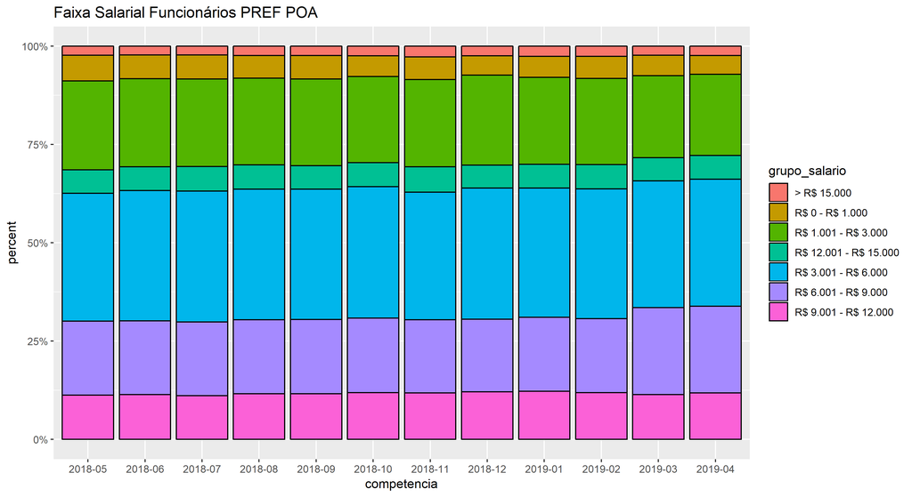

```r
database_salarios %>%
  group_by(
    competencia,
    grupo_salario
  ) %>%
  summarise(
    count = n(),
    salario = sum(salario_liquido)
  ) %>%
  mutate(
    percent = count/sum(count)
  ) %>%
  ggplot(aes(x = competencia, y = percent, fill = grupo_salario)) +
  geom_bar(stat = 'identity', colour = 'black') +
  scale_y_continuous(labels=scales::percent) +
  labs(title = 'Faixa Salarial Funcionários PREF POA')
```

```r
database_salarios %>%
  group_by(
    competencia,
    orgao,
    grupo_salario
  ) %>%
  summarise(
    count = n()
  ) %>%
  mutate(
    percent = count/sum(count)
  ) %>%
  ggplot(aes(x = competencia, y = percent, fill = grupo_salario)) +
  geom_bar(stat = 'identity', colour = 'black') +
  scale_y_continuous(labels=scales::percent) +
  labs(title = 'Faixa Salarial Funcionários PREF POA') +
  facet_wrap(~ orgao, ncol = 3, scale = 'free_y')
```

[figure not shown]

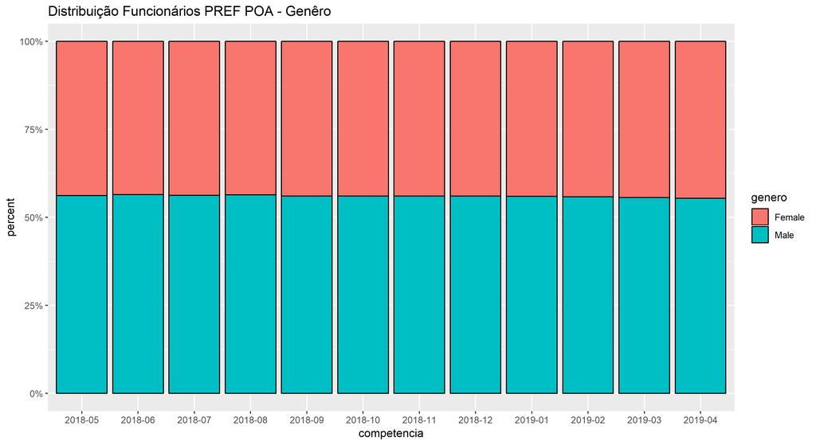

```r
database_salarios %>%
  filter(
    !is.na(genero)
  ) %>%
  group_by(
    competencia,
    genero
  ) %>%
  summarise(
    count = n()
  ) %>%
  mutate(
    percent = count/sum(count)
  ) %>%
  ggplot(aes(x = competencia, y = percent, fill = genero)) +
  geom_bar(stat = 'identity', colour = 'black') +
  scale_y_continuous(labels=scales::percent) +
  labs(title = 'Distribuição Funcionários PREF POA - Gênero')
```

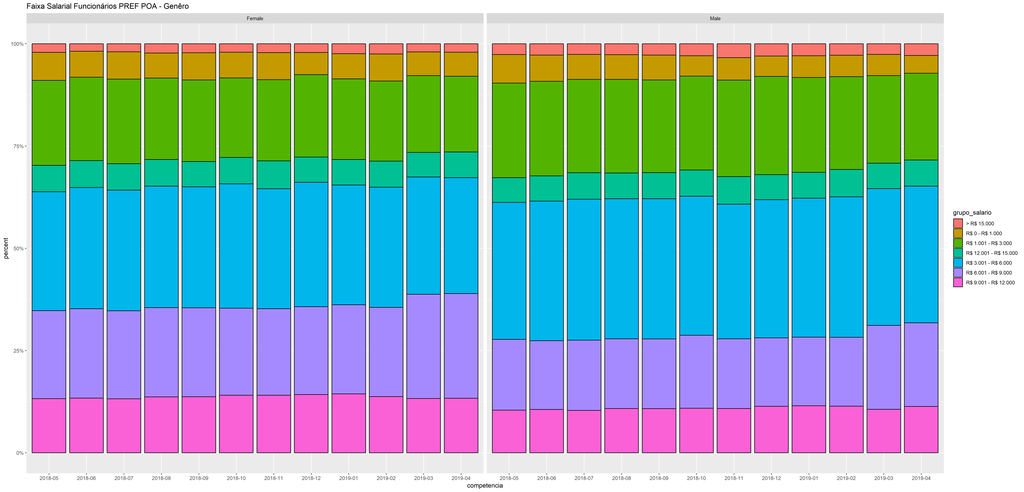

```r
database_salarios %>%
  filter(
    !is.na(genero)
  ) %>%
  group_by(
    competencia,
    genero,
    grupo_salario
  ) %>%
  summarise(
    count = n()
  ) %>%
  mutate(
    percent = count/sum(count)
  ) %>%
  ggplot(aes(x = competencia, y = percent, fill = grupo_salario)) +
  geom_bar(stat = 'identity', colour = 'black') +
  scale_y_continuous(labels=scales::percent) +
  labs(title = 'Faixa Salarial Funcionários PREF POA - Gênero') +
  facet_wrap(~ genero)
```

## Conclusão

[figure not shown]